# Домашнее задание по Автоматизации обработки данных

Authors

[Иванов Никита](https://github.com/nikman370)

[Акименкова Александра](https://github.com/akimaldm-png)

[Зорина Елена](https://github.com/el-zorina)

[Александрова Полина](https://github.com/a-polina-n)

Каждый **самостоятельно** заполняет сведения о себе в разделе `author` выше, делает коммит и загружает в репозиторий. В поле `url` укажите ссылку на свой GitHub. В поле `roles` укажите свою роль или данные, за которые отвечаете. См. [документацию Quarto](https://quarto.org/docs/authoring/front-matter.html#authors-and-affiliations).

## 1. Импорт и очистка данных

Сначала один из участников выполняет раздел 1.1 и загружает результат в ветку `main` на GitHub. После этого каждый выполняет выбранный им раздел 1.2-1.4 в своей ветке.

### 1.1. Пациенты

В файле `data/dm.csv` содержатся демографические данные участников исследования. Вам понадобятся следующие столбцы:

- `USUBJID` — уникальный идентификатор участника
- `AGE` — возраст на момент скрининга, полных лет
- `SEX` — пол участника
- `ARM` — группа лечения
1. Импортируйте данные.
2. Какой формат у этих данных: длинный или широкий? Объясните ответ.
3. Оставьте только нужные столбцы и переименуйте `USUBJID` в `ID`.

```r
dm <- read_csv("data/dm.csv")
# широкий формат данных, один пациент - одна строка. Все характеристики разложены по отдельным столбцам в этой строке
dm_new <- dm |>
  select(USUBJID, AGE, SEX, ARM) |>
  rename(ID = USUBJID)
nrow(dm_new)
```

```
[1] 306
```

```r
table(dm_new$SEX)
```

```
  F   M
179 127
```

```r
count(dm_new, ARM)
```

```
# A tibble: 4 × 2
  ARM                      n
  <chr>                <int>
1 Placebo                 86
2 Screen Failure          52
3 Xanomeline High Dose    84
4 Xanomeline Low Dose     84
```

4. Проверьте, что каждому участнику соответствует ровно одна строка. Если идентификатор участника встречается несколько раз, выведите все такие строки.

```r
dup_rows <- dm |> # для проверки дублирующихся строк
  filter(duplicated(USUBJID) | duplicated(USUBJID, fromLast = T)) # ищем дубли поаорядку и "снизу вверх", чтобы вывелось обе строки, если они есть (а не одна)
if (nrow(dup_rows) > 0) {
  print(dup_rows)
  stop("Обнаружены дублирующиеся ID")
}

stopifnot(nrow(dup_rows) == 0)
# Дублирующиеся ID не обнаружены
```

5. Выведите общее количество людей, оцененных для включения в исследование.
6. Какой процент не прошел скрининг?
7. Оставьте участников с группами лечения из вашего варианта. Преобразуйте столбец `ARM` в фактор и выведите число участников в каждой группе.
8. Сохраните финальный датафрейм в переменную `dm`.

```r
nrow(dm_new)
```

```
[1] 306
```

```r
mean(dm_new$ARM == "Screen Failure") * 100 # процент не прошедших скрининг
```

```
[1] 16.99346
```

```r
dm_arm <- dm_new |>
  filter(ARM %in% c("Placebo", "Xanomeline High Dose")) |>
  mutate(ARM = factor(ARM))
table(dm_arm$ARM)
```

```
             Placebo Xanomeline High Dose
                  86                   84
```

```r
dm <- dm_arm
```

### 1.2. Лабораторные измерения

Файл `data/lb.csv` содержит результаты лабораторных измерений участников исследования. Вам понадобятся следующие столбцы:

- `USUBJID` — уникальный идентификатор участника
- `LBTESTCD` / `LBTEST` — код / название лабораторного теста
- `LBSTRESN` — числовой результат измерения
- `VISIT` — визит измерения
1. Импортируйте данные.
2. Какой формат у этих данных: длинный или широкий? Объясните ответ. Какое минимальное и максимальное число строк на одного пациента?
3. На каких визитах выполняли измерения и какие лабораторные показатели измеряли? Отдельно выведите или подчеркните визиты, на которых измеряли витамин B12.

```r
lb <- read_csv("data/lb.csv")
# длинный формат данных, один пациент встречается много раз. Значения разных тестов лежат не в отдельных столбцах, а друг под другом в одном столбце LBSTRESN, а какой это тест - в LBTEST

lb_new <- lb |>
  select(USUBJID, LBTESTCD, LBTEST, LBSTRESN, VISIT) |>
  rename(ID = USUBJID)

patient_rows <- lb_new |>
  count(ID) # считаем строки на одного пациента
min(patient_rows$n)
```

```
[1] 9
```

```r
max(patient_rows$n)
```

```
[1] 58
```

```r
distinct(lb_new, VISIT) # на каких визитах выполняли измерения
```

```
# A tibble: 7 × 1
  VISIT
  <chr>
1 WEEK 4
2 WEEK 6
3 WEEK 8
4 WEEK 12
5 SCREENING 1
6 WEEK 2
7 BASELINE
```

```r
count(lb_new, VISIT) # сколько измерений на каждом визите
```

```
# A tibble: 7 × 2
  VISIT           n
  <chr>       <int>
1 BASELINE        8
2 SCREENING 1  2448
3 WEEK 12      1326
4 WEEK 2       1918
5 WEEK 4       1765
6 WEEK 6       1594
7 WEEK 8       1495
```

```r
distinct(lb_new, LBTEST) # какие лабораторные показатели измеряли
```

```
# A tibble: 10 × 1
   LBTEST
   <chr>
 1 Basophils
 2 Eosinophils
 3 Hemoglobin
 4 Lymphocytes
 5 Monocytes
 6 Platelet
 7 Erythrocytes
 8 Thyrotropin
 9 Vitamin B12
10 Leukocytes
```

```r
count(lb_new, LBTEST) # сколько измерений на каждом тесте
```

```
# A tibble: 10 × 2
   LBTEST           n
   <chr>        <int>
 1 Basophils     1252
 2 Eosinophils   1252
 3 Erythrocytes  1265
 4 Hemoglobin    1265
 5 Leukocytes    1265
 6 Lymphocytes   1252
 7 Monocytes     1252
 8 Platelet      1252
 9 Thyrotropin    251
10 Vitamin B12    248
```

```r
b12 <- lb_new |>
  filter(LBTEST == "Vitamin B12") |>
  distinct(VISIT)
b12 # визиты, на которых измеряли витамин B12
```

```
# A tibble: 1 × 1
  VISIT
  <chr>
1 SCREENING 1
```

4. Оставьте только участников своей команды. Используйте для этого датафрейм `dm`, созданный координатором в разделе 1.1.
5. Оставьте только два лабораторных показателя своей команды, измеренных на визите `SCREENING 1`.
6. После фильтрации выведите число измерений каждого показателя.

```r
lb_team <- lb_new |>
  semi_join(dm, by = "ID") # оставляем только наших участников, берем только те ID, которые есть в dm
lb_team_filtred <- lb_team |>
  filter(LBTESTCD %in% c("HGB", "LYM"), VISIT == "SCREENING 1") # оствляем только нужные показатели и визит
count(lb_team_filtred, LBTESTCD) # число измерений каждого показателя
```

```
# A tibble: 2 × 2
  LBTESTCD     n
  <chr>    <int>
1 HGB        166
2 LYM        161
```

7. Переведите данные в широкий формат и сохраните в переменную `lb_wide`. В датафрейме должна быть одна строка на одного участника и по крайней мере два столбца с показателями вашей команды. Идентификатор участника должен находиться в столбце с названием `ID`.

```r
lb_wide <- lb_team_filtred |>
  select(ID, LBTESTCD, LBSTRESN) |>
  pivot_wider(names_from = LBTESTCD, values_from = LBSTRESN)
```

8. Проверьте, что `lb_wide` содержит ровно одну строку на одного участника.

```r
dup_check <- lb_wide |>
  count(ID) |>
  filter(n > 1)
if (nrow(dup_check) > 0) {
  print(dup_check)
  stop("Обнаружены повторяющиеся ID")
}
stopifnot(nrow(lb_wide) == n_distinct(lb_wide$ID)) # сравниваем количество строк с количеством уникальных значений в столбце ID
```

### 1.3. Витальные показатели

Файл `data/vs.csv` содержит результаты измерений витальных показателей участников исследования, включая рост и вес. Вам понадобятся следующие столбцы:

- `USUBJID` — уникальный идентификатор участника
- `VSTESTCD` / `VSTEST` — код / название измеряемого показателя
- `VSSTRESN` — числовой результат измерения
- `VISIT` — визит исследования
1. Импортируйте данные.
2. Какой формат у этих данных: длинный или широкий? Объясните ответ. Какое минимальное и максимальное число строк на одного участника?
3. На каких визитах измеряли рост (`HEIGHT`) и вес (`WEIGHT`)?

```r
# 1. Импорт данных по витальным показателям
vs <- read_csv("data/vs.csv")
# 2. Формат данных и число строк на пациента
#формат данных длинный: одна строка - один показатель измерения при конкретном визите
vs |>
  count(USUBJID) |>
  summarise(min_rows = min(n), max_rows = max(n))
```

```
# A tibble: 1 × 2
  min_rows max_rows
     <int>    <int>
1       21       71
```

```r
# 3. Визиты, на которых измеряли рост и вес
vs |>
  filter(VSTESTCD %in% c("HEIGHT", "WEIGHT")) |>
  distinct(VSTESTCD, VISIT) |>
  arrange(VSTESTCD, VISIT)
```

```
# A tibble: 8 × 2
  VSTESTCD VISIT
  <chr>    <chr>
1 HEIGHT   SCREENING 1
2 WEIGHT   BASELINE
3 WEIGHT   SCREENING 1
4 WEIGHT   WEEK 12
5 WEIGHT   WEEK 2
6 WEIGHT   WEEK 4
7 WEIGHT   WEEK 6
8 WEIGHT   WEEK 8
```

4. Оставьте только участников своей команды. Используйте для этого датафрейм `dm`, созданный координатором в разделе 1.1.
5. Оставьте измерения роста и веса на визите `SCREENING 1`, а также измерения веса на визите вашей команды.

```r
# 4-5. Фильтрация по росту и весу на SCREENING 1, вес на WEEK 4
vs_filtered <- vs |>
  select(USUBJID, VSTESTCD, VSSTRESN, VISIT) |>
  semi_join(dm, by = c("USUBJID" = "ID")) |>
  filter(
    VSTESTCD %in% c("HEIGHT", "WEIGHT"),
    VISIT == "SCREENING 1" | (VSTESTCD == "WEIGHT" & VISIT == "WEEK 4")
  )
```

6. Переведите данные в широкий формат и сохраните в переменной `vs_wide`. В датафрейме должны быть столбцы для всех трёх отобранных измерений. Подсказка: значение, которое вы передаёте в `names_from`, должно быть уникальным для каждого участника. Проверьте это до вызова `pivot_wider()`. Идентификатор участника должен находиться в столбце с названием `ID`.

```r
# 6. Уникальные метки измерений для pivot_wider
vs_labeled <- vs_filtered |>
  mutate(
    measure = case_when(
      VSTESTCD == "HEIGHT" & VISIT == "SCREENING 1" ~ "HEIGHT_SCR",
      VSTESTCD == "WEIGHT" & VISIT == "SCREENING 1" ~ "WEIGHT_SCR",
      VSTESTCD == "WEIGHT" & VISIT == "WEEK 4" ~ "WEIGHT_WK4"
    )
  )

# Широкий формат
vs_wide <- vs_labeled |>
  select(USUBJID, measure, VSSTRESN) |>
  pivot_wider(names_from = measure, values_from = VSSTRESN) |>
  rename(ID = USUBJID)
```

7. Проверьте, что `vs_wide` содержит ровно одну строку на участника.

```r
# 7. Проверка: одна строка на участника
stopifnot(nrow(vs_wide) == n_distinct(vs_wide$ID))
vs_wide
```

```
# A tibble: 170 × 4
   ID          HEIGHT_SCR WEIGHT_SCR WEIGHT_WK4
   <chr>            <dbl>      <dbl>      <dbl>
 1 01-701-1015       147.       54.0       54.0
 2 01-701-1023       163.       78.5       80.3
 3 01-701-1028       178.       98.9       98.9
 4 01-701-1034       155.       63.5       64.0
 5 01-701-1047       149.       66.2       67.6
 6 01-701-1118       180.       71.7       71.2
 7 01-701-1130       170.       79.4       78.0
 8 01-701-1133       163.       74.8       74.4
 9 01-701-1146       147.       54.0       54.4
10 01-701-1148       175.       86.2       88.9
# ℹ 160 more rows
```

### 1.4. Генотип APOE

Файл `data/gf.csv` содержит результаты генотипирования участников исследования. Вам понадобятся следующие столбцы:

- `USUBJID` — уникальный идентификатор участника
- `GFORRES` — выявленный генотип
- `GFSYM` — символ гена
- `GFPVRID` — идентификатор генетического варианта
- `VISIT` — визит исследования
1. Импортируйте данные.
2. Какой формат у этих данных: длинный или широкий? Объясните ответ.

Формат данных длинный - на каждого участника приходится много строк, в каждой строке отдельный генетический вариант.

Какое минимальное и максимальное число строк на одного участника?

У каждого участника ровно по 12 строк.

```r
gf <- read_csv("data/gf.csv", col_types = cols(GFGENLOC = col_character())) # добавила аргумент col_types для избежания прочтения данных как дат, хотя этот столбец нам в дальнейшем и не нужен

gf_new <- gf |>
  select(USUBJID, GFORRES, GFSYM, GFPVRID, VISIT) |>
  rename(ID = USUBJID)

gf_new |>
  count(ID) |>
  summarise(min_rows = min(n), max_rows = max(n))
```

```
# A tibble: 1 × 2
  min_rows max_rows
     <int>    <int>
1       12       12
```

3. Оставьте только участников своей команды. Используйте для этого датафрейм `dm`, созданный координатором в разделе 1.1 выше.
4. Оставьте только ген `APOE` и варианты с идентификаторами `rs429358` и `rs7412`.

```r
gf_filtered <- gf_new |>
  semi_join(dm, by = 'ID') |>
  filter(GFSYM == 'APOE' & GFPVRID == 'rs429358' | GFPVRID == 'rs7412')
```

5. По таблице ниже определите генотип APOE для каждого участника. Для комбинации, которой нет в таблице, присвойте значение `NA`.

| rs429358 | rs7412 | Генотип APOE |
| --- | --- | --- |
| T/T | T/T | ε2/ε2 |
| T/T | C/T | ε2/ε3 |
| T/C | C/T | ε2/ε4 |
| T/T | C/C | ε3/ε3 |
| T/C | C/C | ε3/ε4 |
| C/C | C/C | ε4/ε4 |

6. Выведите число участников с каждым генотипом APOE.
7. Сохраните итоговый датафрейм в переменную `gf_wide`. Идентификатор участника должен находиться в столбце `ID`.

```r
gf_wide <-
  gf_filtered |>
  pivot_wider(
    names_from = GFPVRID,
    values_from = GFORRES
  )

gf_wide <- gf_wide |>
  mutate(
    GT_APOE = case_when(
      rs429358 == "T/T" & rs7412 == "T/T" ~ "ε2/ε2",
      rs429358 == "T/T" & rs7412 == "C/T" ~ "ε2/ε3",
      rs429358 == "T/C" & rs7412 == "C/T" ~ "ε2/ε4",
      rs429358 == "T/T" & rs7412 == "C/C" ~ "ε3/ε3",
      rs429358 == "T/C" & rs7412 == "C/C" ~ "ε3/ε4",
      rs429358 == "C/C" & rs7412 == "C/C" ~ "ε4/ε4",
      TRUE ~ NA
    )
  )

gf_wide |>
  count(GT_APOE)
```

```
# A tibble: 6 × 2
  GT_APOE     n
  <chr>   <int>
1 ε2/ε2       1
2 ε2/ε3      19
3 ε2/ε4       6
4 ε3/ε3      78
5 ε3/ε4      59
6 ε4/ε4       7
```

8. Проверьте, что `gf_wide` содержит ровно одну строку на участника.

```r
stopifnot(nrow(gf_wide) == n_distinct(gf_wide$ID))
```

## 2. Объединение данных

Этот раздел выполняет координатор. Он переносит в основную ветку `main` пункты 1.2-1.4, выполненные участниками в своих ветках.

После объединения веток отчёт должен создавать четыре датафрейма: `dm`, `lb_wide`, `vs_wide` и `gf_wide`. Все датафреймы должны быть в широком формате: по одной строке на участника. Присоедините `lb_wide`, `vs_wide` и `gf_wide` к `dm` по столбцу `ID`. Сохраните результат в отдельную переменную для дальнейшего анализа.

```r
# Объединение всех датафреймов в один (data_merged) по столбцу ID
data_merged <- dm |>
  left_join(lb_wide, by = "ID") |>
  left_join(vs_wide, by = "ID") |>
  left_join(gf_wide, by = "ID")
```

Проверьте, что число строк в результате совпадает с числом участников в `dm` и что не появилось повторяющихся значений `ID`.

```r
stopifnot(nrow(data_merged) == nrow(dm)) # Проверяем равенство строк, если будет неравно - то выдаст ошибку

duplicates <- data_merged |> # Считаем, сколько раз встречается каждый ID
  count(ID) |>
  filter(n > 1)

if (nrow(duplicates) > 0) {
  # Если нашли хотя бы один дубликат (>0), выдаем сообщением
  stop("Ошибка: В объединенной таблице обнаружены повторяющиеся значения ID!")
} else {
  message("Проверка пройдена успешно: дубликатов ID не обнаружено.")
}
```

```
Проверка пройдена успешно: дубликатов ID не обнаружено.
```

Для каждого столбца итогового датафрейма выведите число непустых и число пропущенных значений.

```r
missing_count <- colSums(is.na(data_merged)) # Считаем пропущенные и непустые значения
complete_count <- colSums(!is.na(data_merged))

# Собираем в таблицу
na_table <- data.frame(Missing = missing_count, Complete = complete_count)

# Выводим в терминал значения
print(na_table)
```

```
           Missing Complete
ID               0      170
AGE              0      170
SEX              0      170
ARM              0      170
HGB              4      166
LYM              9      161
HEIGHT_SCR       0      170
WEIGHT_SCR       0      170
WEIGHT_WK4      16      154
GFSYM            0      170
VISIT            0      170
rs429358         0      170
rs7412           0      170
GT_APOE          0      170
```

## 3. Описательные статистики и отчёт

Каждый выполняет свой подраздел в отдельной ветке, используя объединенные данные. Перед началом работы переключитесь на ветку `main`, получите актуальные изменения и убедитесь, что вам доступен объединённый датафрейм с данными других членов команды.

Координатор объединяет подразделы и проверяет результаты. Проверьте согласованность значений в таблицах между разделами: например, минимум и максимум по всей таблице должны совпадать независимо от группировки. Если есть расхождения, найдите причину и опишите её: например, различия в фильтрации, группировке или обработке пропусков.

### 3.1. Анализ лабораторных результатов

1. Для каждого лабораторного показателя рассчитайте статистики в каждой группе лечения. В таблице приведите:
   - число непустых значений
   - число пропущенных значений
   - среднее (стандартное отклонение)
   - медиана [25-й, 75-й процентили]
   - минимум - максимум
2. Постройте такую же таблицу для носителей и неносителей аллеля ε4.
3. Оформите результаты в таблицы `flextable` с заголовками на русском или английском языке с указанием единиц измерения.
4. Кратко прокомментируйте результаты, приведённые в таблицах.

```r
# Переводим HGB и LYM из широкого формата в длинный, чтобы удобно считать статистики сразу по обоим показателям
lab_long <- data_merged |>
  pivot_longer(cols = c(HGB, LYM), names_to = "test", values_to = "value")

# Считаем статистики по каждому лабораторному показателю в каждой группе лечения (ARM)
lab_stats_arm <- lab_long |>
  group_by(ARM, test) |>
  summarise(
    n = sum(!is.na(value)), # число непустых значений
    n_missing = sum(is.na(value)), # число пропущенных значений
    mean = mean(value, na.rm = TRUE), # среднее
    sd = sd(value, na.rm = TRUE), # стандартное отклонение
    median = median(value, na.rm = TRUE), # медиана
    q25 = quantile(value, 0.25, na.rm = TRUE), # 25-й процентиль
    q75 = quantile(value, 0.75, na.rm = TRUE), # 75-й процентиль
    min = min(value, na.rm = TRUE), # минимум
    max = max(value, na.rm = TRUE), # максимум
    .groups = "drop"
  )

# Создаём переменную носитель/неноситель аллеля ε4 по столбцу GT_APOE
data_merged <- data_merged |>
  mutate(
    e4_status = case_when(
      str_detect(GT_APOE, "ε4") ~ "Носитель ε4",
      TRUE ~ "Неноситель ε4"
    )
  )

# Те же статистики, но теперь в разбивке по статусу носительства ε4
lab_stats_e4 <- data_merged |>
  pivot_longer(cols = c(HGB, LYM), names_to = "test", values_to = "value") |>
  group_by(e4_status, test) |>
  summarise(
    n = sum(!is.na(value)),
    n_missing = sum(is.na(value)),
    mean = mean(value, na.rm = TRUE),
    sd = sd(value, na.rm = TRUE),
    median = median(value, na.rm = TRUE),
    q25 = quantile(value, 0.25, na.rm = TRUE),
    q75 = quantile(value, 0.75, na.rm = TRUE),
    min = min(value, na.rm = TRUE),
    max = max(value, na.rm = TRUE),
    .groups = "drop"
  )

# Объединяем числа в удобные для чтения строки
format_stats <- function(df, group_col) {
  df |>
    mutate(
      `Среднее (СО)` = str_c(round(mean, 1), " (", round(sd, 1), ")"),
      `Медиана [25%; 75%]` = str_c(
        round(median, 1),
        " [",
        round(q25, 1),
        "; ",
        round(q75, 1),
        "]"
      ),
      `Мин – Макс` = str_c(round(min, 1), " – ", round(max, 1))
    ) |>
    select(
      {{ group_col }},
      test,
      n,
      n_missing,
      `Среднее (СО)`,
      `Медиана [25%; 75%]`,
      `Мин – Макс`
    )
}

# Таблица по группам лечения
ft_arm <- format_stats(lab_stats_arm, ARM) |>
  flextable() |>
  set_header_labels(
    ARM = "Группа лечения",
    test = "Показатель",
    n = "N (непустых)",
    n_missing = "Пропущено"
  ) |>
  autofit()

# Таблица по статусу носительства ε4
ft_e4 <- format_stats(lab_stats_e4, e4_status) |>
  flextable() |>
  set_header_labels(
    e4_status = "Статус ε4",
    test = "Показатель",
    n = "N (непустых)",
    n_missing = "Пропущено"
  ) |>
  autofit()

# Выводим обе таблицы
ft_arm
```

| Группа лечения | Показатель | N (непустых) | Пропущено | Среднее (СО) | Медиана [25%; 75%] | Мин – Макс |
| --- | --- | --- | --- | --- | --- | --- |
| Placebo | HGB | 85 | 1 | 8.6 (0.8) | 8.6 [8.1; 9.2] | 6.4 – 10.4 |
| Placebo | LYM | 82 | 4 | 1.8 (0.6) | 1.8 [1.4; 2.1] | 0.8 – 3.9 |
| Xanomeline High Dose | HGB | 81 | 3 | 8.9 (0.8) | 8.9 [8.3; 9.4] | 7.4 – 10.6 |
| Xanomeline High Dose | LYM | 79 | 5 | 1.7 (0.5) | 1.6 [1.3; 2] | 0.7 – 3 |

```r
ft_e4
```

| Статус ε4 | Показатель | N (непустых) | Пропущено | Среднее (СО) | Медиана [25%; 75%] | Мин – Макс |
| --- | --- | --- | --- | --- | --- | --- |
| Неноситель ε4 | HGB | 95 | 3 | 8.7 (0.8) | 8.7 [8.3; 9.2] | 6.4 – 10.4 |
| Неноситель ε4 | LYM | 93 | 5 | 1.7 (0.5) | 1.6 [1.3; 2] | 0.8 – 3.9 |
| Носитель ε4 | HGB | 71 | 1 | 8.8 (0.9) | 8.8 [8.1; 9.4] | 7.1 – 10.6 |
| Носитель ε4 | LYM | 68 | 4 | 1.8 (0.6) | 1.7 [1.4; 2.1] | 0.7 – 3.3 |

По группам лечения HGB у Xanomeline High Dose в среднем немного выше, чем у Placebo, но разница небольшая. LYM практически не различаются между группами. Пропущенных значений немного - не должно сильно влиять на результаты.

По статусу носительства ε4 - значимых значений между группами не наблюдается.

### 3.2. Анализ витальных показателей

1. Рассчитайте BMI на скрининге.
2. Создайте категорию BMI: норма для значений в диапазоне [18.5, 25) и не норма для значений вне этого диапазона.
3. Представьте BMI по группам лечения в двух вариантах:
   - как количественный показатель со следующими отформатированными статистиками:
     - число непустых значений
     - число пропущенных значений
     - среднее (стандартное отклонение)
     - медиана [25-й, 75-й процентили]
     - минимум - максимум
   - как категорию норма / не норма:
     - число участников (процент).
4. Вычислите число аллелей ε4 (0 / 1 / 2) у каждого участника и представьте BMI по этим категориям.
5. Оформите результаты в таблицы `flextable` с заголовками на русском или английском языке.
6. Кратко прокомментируйте результаты, приведённые в таблицах.

```r
# 1. BMI на скрининге
data_bmi <- data_merged |>
  mutate(
    BMI = WEIGHT_SCR / (HEIGHT_SCR / 100)^2  # рост из см в м
  )

# 2. Категория BMI: норма [18.5; 25) / не норма — вне диапазона
data_bmi <- data_bmi |>
  mutate(
    BMI_CAT = case_when(
      BMI >= 18.5 & BMI < 25 ~ "Норма",
      !is.na(BMI)            ~ "Не норма",
      TRUE                   ~ NA_character_
    )
  )

# 3. BMI по группам лечения в двух вариантах:
#    3a — как количественный показатель,
#    3b — как категория норма / не норма

# 3a. Количественный показатель: N, пропуски, среднее (СО),
#     медиана [25%; 75%], мин – макс
bmi_stats_arm <- data_bmi |>
  group_by(ARM) |>
  summarise(
    n         = sum(!is.na(BMI)),
    n_missing = sum(is.na(BMI)),
    mean      = mean(BMI, na.rm = TRUE),
    sd        = sd(BMI, na.rm = TRUE),
    median    = median(BMI, na.rm = TRUE),
    q25       = quantile(BMI, 0.25, na.rm = TRUE),
    q75       = quantile(BMI, 0.75, na.rm = TRUE),
    min       = min(BMI, na.rm = TRUE),
    max       = max(BMI, na.rm = TRUE),
    .groups   = "drop"
  )

# 3b. Категория норма / не норма: число участников (процент)
bmi_cat_arm <- data_bmi |>
  filter(!is.na(BMI_CAT)) |>
  count(ARM, BMI_CAT) |>
  group_by(ARM) |>
  mutate(
    pct   = round(n / sum(n) * 100, 1),
    value = str_c(n, " (", pct, "%)")
  ) |>
  ungroup() |>
  select(ARM, BMI_CAT, value) |>
  pivot_wider(names_from = BMI_CAT, values_from = value)

# 4. Число аллелей ε4 (0 / 1 / 2) у каждого участника
#    и BMI по этим категориям
data_bmi <- data_bmi |>
  mutate(
    e4_count = case_when(
      GT_APOE == "ε4/ε4"                            ~ 2L,
      GT_APOE %in% c("ε3/ε4", "ε2/ε4")              ~ 1L,
      GT_APOE %in% c("ε3/ε3", "ε2/ε3", "ε2/ε2")     ~ 0L,
      TRUE                                           ~ NA_integer_
    )
  )

bmi_stats_e4 <- data_bmi |>
  filter(!is.na(e4_count)) |>
  group_by(e4_count) |>
  summarise(
    n         = sum(!is.na(BMI)),
    n_missing = sum(is.na(BMI)),
    mean      = mean(BMI, na.rm = TRUE),
    sd        = sd(BMI, na.rm = TRUE),
    median    = median(BMI, na.rm = TRUE),
    q25       = quantile(BMI, 0.25, na.rm = TRUE),
    q75       = quantile(BMI, 0.75, na.rm = TRUE),
    min       = min(BMI, na.rm = TRUE),
    max       = max(BMI, na.rm = TRUE),
    .groups   = "drop"
  ) |>
  mutate(e4_count = factor(e4_count, levels = 0:2))

# 5. Оформление результатов

format_bmi_stats <- function(df, group_col) {
  df |>
    mutate(
      `Среднее (СО)` = str_c(round(mean, 1), " (", round(sd, 1), ")"),
      `Медиана [25%; 75%]` = str_c(
        round(median, 1),
        " [",
        round(q25, 1),
        "; ",
        round(q75, 1),
        "]"
      ),
      `Мин – Макс` = str_c(round(min, 1), " – ", round(max, 1))
    ) |>
    select(
      {{ group_col }},
      n,
      n_missing,
      `Среднее (СО)`,
      `Медиана [25%; 75%]`,
      `Мин – Макс`
    )
}

# Таблица 3a. BMI по группам лечения — количественный показатель
ft_bmi_arm <- format_bmi_stats(bmi_stats_arm, ARM) |>
  flextable() |>
  set_header_labels(
    ARM       = "Группа лечения",
    n         = "N (непустых)",
    n_missing = "Пропущено"
  ) |>
  set_caption("BMI на скрининге по группам лечения, кг/м²") |>
  autofit()

# Таблица 3b. Категория BMI по группам лечения — n (%)
ft_bmi_cat <- bmi_cat_arm |>
  flextable() |>
  set_header_labels(ARM = "Группа лечения") |>
  set_caption("Категория BMI на скрининге по группам лечения: n (%)") |>
  autofit()

# Таблица 4. BMI по числу аллелей ε4 — количественный показатель
ft_bmi_e4 <- format_bmi_stats(bmi_stats_e4, e4_count) |>
  flextable() |>
  set_header_labels(
    e4_count  = "Число аллелей ε4",
    n         = "N (непустых)",
    n_missing = "Пропущено"
  ) |>
  set_caption("BMI на скрининге по числу аллелей ε4, кг/м²") |>
  autofit()

# Выводим три таблицы
ft_bmi_arm
```

| Группа лечения | N (непустых) | Пропущено | Среднее (СО) | Медиана [25%; 75%] | Мин – Макс |
| --- | --- | --- | --- | --- | --- |
| Placebo | 86 | 0 | 23.6 (3.6) | 23.2 [21.1; 25.7] | 15.7 – 34 |
| Xanomeline High Dose | 84 | 0 | 25.4 (4) | 24.7 [23; 28.1] | 15 – 35.5 |

```r
ft_bmi_cat
```

| Группа лечения | Не норма | Норма |
| --- | --- | --- |
| Placebo | 31 (36%) | 55 (64%) |
| Xanomeline High Dose | 38 (45.2%) | 46 (54.8%) |

```r
ft_bmi_e4
```

| Число аллелей ε4 | N (непустых) | Пропущено | Среднее (СО) | Медиана [25%; 75%] | Мин – Макс |
| --- | --- | --- | --- | --- | --- |
| 0 | 98 | 0 | 24.5 (3.9) | 23.9 [21.7; 26.9] | 15.7 – 35.5 |
| 1 | 65 | 0 | 24.8 (3.9) | 24.5 [22.5; 27.3] | 15 – 34 |
| 2 | 7 | 0 | 22.2 (2.1) | 21.9 [20.6; 23.7] | 19.3 – 25.1 |

### 3.3. Анализ генотипа

1. Для каждой группы лечения рассчитайте число и процент участников с каждым генотипом APOE.
2. В одной таблице рассчитайте статистики BMI и лабораторных показателей в зависимости от генотипа APOE:
   - число непустых значений
   - число пропущенных значений
   - среднее (стандартное отклонение)
   - медиана [25-й, 75-й процентили]
   - минимум - максимум
3. Оформите результаты в `flextable` с заголовками на русском или английском языке, укажите единицы измерения.
4. Кратко прокомментируйте результаты, приведённые в таблицах.

```r
# 1
apoe_treatment <- data_merged |>
  group_by(ARM, GT_APOE) |>
  summarise(
    n = n(),
    .groups = "drop"
  )
apoe_treatment <- apoe_treatment |>
  group_by(ARM) |>
  mutate(
    percent = round(n / sum(n) * 100, 2)
  )

ft_apoe_1 <- apoe_treatment %>%
  flextable() %>%
  set_header_labels(
    ARM = "Группа лечения",
    GT_APOE = "Генотип APOE",
    n = "Число участников",
    percent = "Доля, %"
  ) %>%
  autofit()

# 2
# поскольку в основной таблице data_merged данных по BMI нет, во избежание дуплицирования обсчетов, я использовала данные по BMI, использованные в секции 3.2
idbmi <- data_bmi |>
  select(ID, BMI)

apoe_bmi <- data_merged |>
  left_join(idbmi, by = "ID")

apoe_table <- apoe_bmi |>
  group_by(GT_APOE) |>
  summarise(
    BMI_n = sum(!is.na(BMI)), # число непустых значений
    BMI_missing = sum(is.na(BMI)), # число пропущенных значений
    BMI_mean = mean(BMI, na.rm = TRUE), # среднее
    BMI_sd = sd(BMI, na.rm = TRUE), # стандарноте отклонение
    BMI_median = median(BMI, na.rm = TRUE),
    BMI_q25 = quantile(BMI, 0.25, na.rm = TRUE),
    BMI_q75 = quantile(BMI, 0.75, na.rm = TRUE),
    BMI_min = min(BMI, na.rm = TRUE),
    BMI_max = max(BMI, na.rm = TRUE),

    HGB_n = sum(!is.na(HGB)), # число непустых значений
    HGB_missing = sum(is.na(HGB)), # число пропущенных значений
    HGB_mean = mean(HGB, na.rm = TRUE), # среднее
    HGB_sd = sd(HGB, na.rm = TRUE), # стандарноте отклонение
    HGB_median = median(HGB, na.rm = TRUE),
    HGB_q25 = quantile(HGB, 0.25, na.rm = TRUE),
    HGB_q75 = quantile(HGB, 0.75, na.rm = TRUE),
    HGB_min = min(HGB, na.rm = TRUE),
    HGB_max = max(HGB, na.rm = TRUE),

    LYM_n = sum(!is.na(LYM)), # число непустых значений
    LYM_missing = sum(is.na(LYM)), # число пропущенных значений
    LYM_mean = mean(LYM, na.rm = TRUE), # среднее
    LYM_sd = sd(LYM, na.rm = TRUE), # стандарноте отклонение
    LYM_median = median(LYM, na.rm = TRUE),
    LYM_q25 = quantile(LYM, 0.25, na.rm = TRUE),
    LYM_q75 = quantile(LYM, 0.75, na.rm = TRUE),
    LYM_min = min(LYM, na.rm = TRUE),
    LYM_max = max(LYM, na.rm = TRUE),
  )

# 3 собираю в нужный формат

apoe_flextable <- apoe_table |>
  mutate(
    BMI_mean_sd = str_c(
      round(BMI_mean, 2),
      " (",
      round(BMI_sd, 2),
      ")"
      ),
    BMI_median_q = str_c(
      round(BMI_median, 2),
      " [",
      round(BMI_q25, 2),
      ", ",
      round(BMI_q75, 2),
      "]"
    ),
    BMI_range = str_c(
      round(BMI_min, 2),
      " - ",
      round(BMI_max, 2)
    ),

    HGB_mean_sd = str_c(
      round(HGB_mean, 2),
      " (",
      round(HGB_sd, 2),
      ")"
      ),
    HGB_median_q = str_c(
      round(HGB_median, 2),
      " [",
      round(HGB_q25, 2),
      ", ",
      round(HGB_q75, 2),
      "]"
    ),
    HGB_range = str_c(
      round(HGB_min, 2),
      " - ",
      round(HGB_max, 2)
    ),

    LYM_mean_sd = str_c(
      round(LYM_mean, 2),
      " (",
      round(LYM_sd, 2),
      ")"
      ),
    LYM_median_q = str_c(
      round(LYM_median, 2),
      " [",
      round(LYM_q25, 2),
      ", ",
      round(LYM_q75, 2),
      "]"
    ),
    LYM_range = str_c(
      round(LYM_min, 2),
      " - ",
      round(LYM_max, 2)
    ),
  )
# 4

apoe_flextable <- apoe_flextable |>
  select(GT_APOE, BMI_n, BMI_missing, BMI_mean_sd, BMI_median_q, BMI_median_q, BMI_range, HGB_n, HGB_missing, HGB_mean_sd, HGB_median_q, HGB_range, LYM_n, LYM_missing, LYM_mean_sd, LYM_median_q, LYM_range)

ft_apoe_2 <- apoe_flextable |>
  flextable() |>
  set_header_labels(
    GT_APOE = "Генотип APOE",
    BMI_n = "BMI: N (не пустых)",
    BMI_missing = "BMI: N (пропущенных)",
    BMI_mean_sd = "BMI, кг/м²: среднее (SD)",
    BMI_median_q = "BMI, кг/м²: медиана [Q1, Q3]",
    BMI_range = "BMI, кг/м²: min-max",

    HGB_n = "Гемоглобин: N (не пустых)",
    HGB_missing = "Гемоглобин: N (пропущенных)",
    HGB_mean_sd = "Гемоглобин, г/л: среднее (СО)",
    HGB_median_q = "Гемоглобин, г/л: медиана [Q1, Q3]",
    HGB_range = "Гемоглобин, г/л: min-max",

    LYM_n = "Лимфоциты: N (не пустых)",
    LYM_missing = "Лейкоциты: N (пропущенных)",
    LYM_mean_sd = "Лимфоциты, ×10⁹/л: среднее (SD)",
    LYM_median_q = "Лимфоциты, ×10⁹/л: медиана [Q1, Q3]",
    LYM_range = "Лимфоциты, ×10⁹/л: min-max"
  ) |>
  autofit()

# выводим обе таблицы

ft_apoe_1
```

| Группа лечения | Генотип APOE | Число участников | Доля, % |
| --- | --- | --- | --- |
| Placebo | ε2/ε3 | 9 | 10.47 |
| Placebo | ε2/ε4 | 4 | 4.65 |
| Placebo | ε3/ε3 | 41 | 47.67 |
| Placebo | ε3/ε4 | 31 | 36.05 |
| Placebo | ε4/ε4 | 1 | 1.16 |
| Xanomeline High Dose | ε2/ε2 | 1 | 1.19 |
| Xanomeline High Dose | ε2/ε3 | 10 | 11.90 |
| Xanomeline High Dose | ε2/ε4 | 2 | 2.38 |
| Xanomeline High Dose | ε3/ε3 | 37 | 44.05 |
| Xanomeline High Dose | ε3/ε4 | 28 | 33.33 |
| Xanomeline High Dose | ε4/ε4 | 6 | 7.14 |

```r
ft_apoe_2
```

[output not shown]

Наиболее распространённым генотипом APOE в обеих группах лечения был ε3/ε3 (47.67 и 44.05%). Распределение генотипов между группами лечения было довольно неравномерным - целый ряд генотипов представлен единичными участниками. Для BMI и исследуемых лабораторных показателей показателей (гемоглобин, лимфоциты) наблюдались небольшие различия описательных статистик (в частности, среднего) между генотипами APOE, однако статистическая значимость этих различий не оценивалась. Наибольшее варьирование среди генотипов показал уровень гемоглобина (см. график).

## 4. Дополнительные задания

Следующие задания необязательны и могут принести дополнительные баллы, чтобы гарантировать зачет.

### 4.1. Визуализация

Проиллюстрируйте результаты из таблиц раздела 3 графиками.

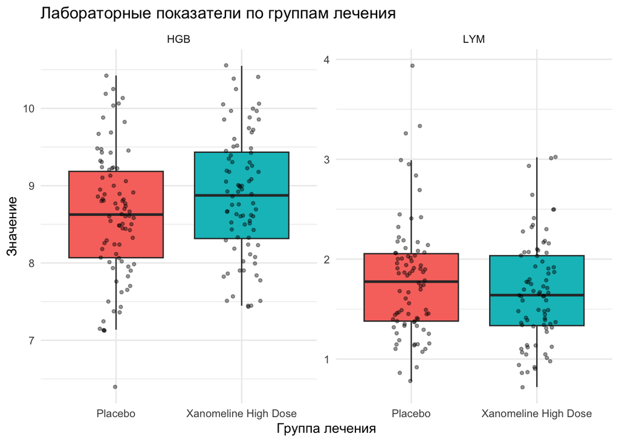

```r
# Визуализация Лабораторные показатели

# Боксплот с точками - показатели по группам лечения (ARM)
ggplot(lab_long, aes(x = ARM, y = value, fill = ARM)) +
  geom_boxplot(outlier.shape = NA) + # боксплот без отдельных выбросов
  geom_jitter(width = 0.15, alpha = 0.4, size = 1) + # точки-наблюдения
  facet_wrap(~test, scales = "free_y") + # отдельная панель для HGB и для LYM, с независимой шкалой Y
  labs(
    title = "Лабораторные показатели по группам лечения",
    x = "Группа лечения",
    y = "Значение"
  ) +
  theme_minimal() +
  theme(legend.position = "none")
```

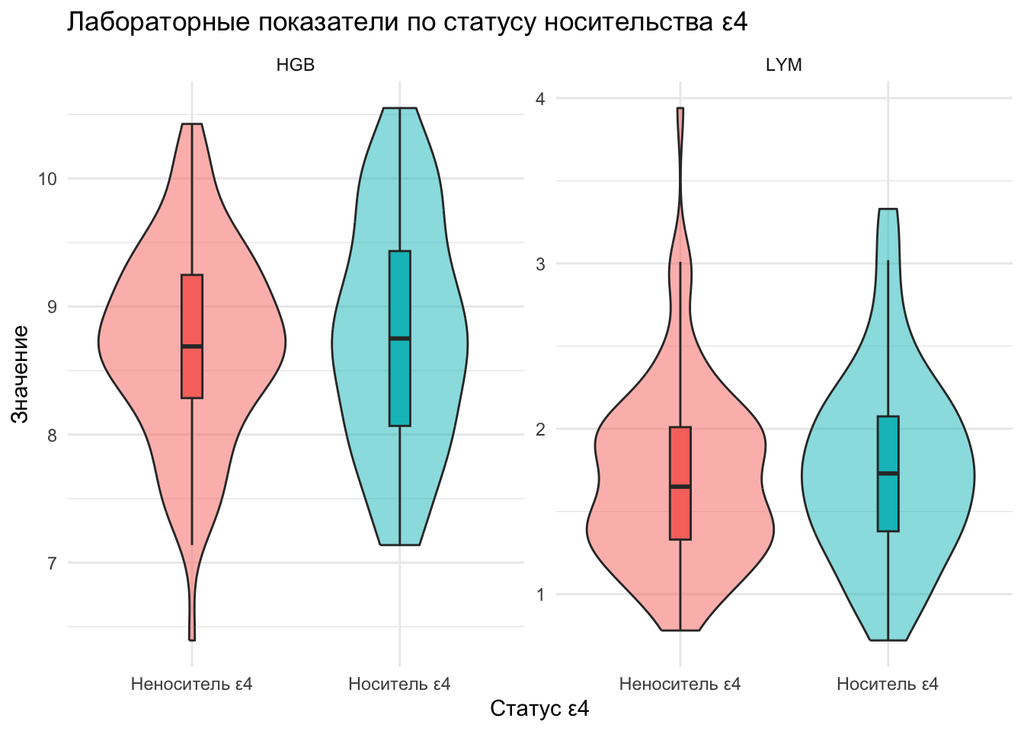

```r
# Данные в длинном формате с добавленным статусом ε4
lab_long_e4 <- data_merged %>%
  pivot_longer(cols = c(HGB, LYM), names_to = "test", values_to = "value")

# Показатели по статусу носительства ε4
ggplot(lab_long_e4, aes(x = e4_status, y = value, fill = e4_status)) +
  geom_violin(alpha = 0.5) + # форма показывает плотность распределения
  geom_boxplot(width = 0.1, outlier.shape = NA) + # узкий боксплот поверх для медианы и разброса
  facet_wrap(~test, scales = "free_y") +
  labs(
    title = "Лабораторные показатели по статусу носительства ε4",
    x = "Статус ε4",
    y = "Значение"
  ) +
  theme_minimal() +
  theme(legend.position = "none")
```

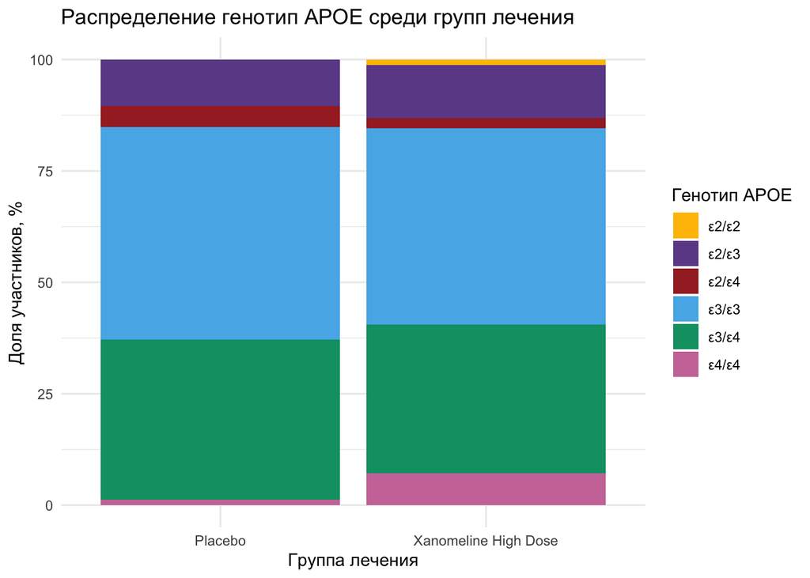

```r
# plot, boxplot, hist

# ggplot
# geom_boxplot, geom_violin
# geom_point, geom_jitter
# facet_wrap

# Визуализация Генотипирование

# Stacked bar по распределению участников с разными генотипами APOE среди групп лечения.

ggplot(apoe_treatment, aes(x = ARM, y = percent, fill = GT_APOE)) +
  geom_col() +
  scale_fill_manual(
    values = c(
      "ε2/ε2" = "#ffbf00",
      "ε2/ε4" = "#A52A2A",
      "ε2/ε3" = "#6e4c97",
      "ε3/ε3" = "#56B4E9",
      "ε3/ε4" = "#009E73",
      "ε4/ε4" = "#CC79A7"
    )
   ) +
  labs(
    title = "Распределение генотип APOE среди групп лечения",
    x = "Группа лечения",
    y = "Доля участников, %",
    fill = "Генотип APOE"
  ) +
  theme_minimal()
```

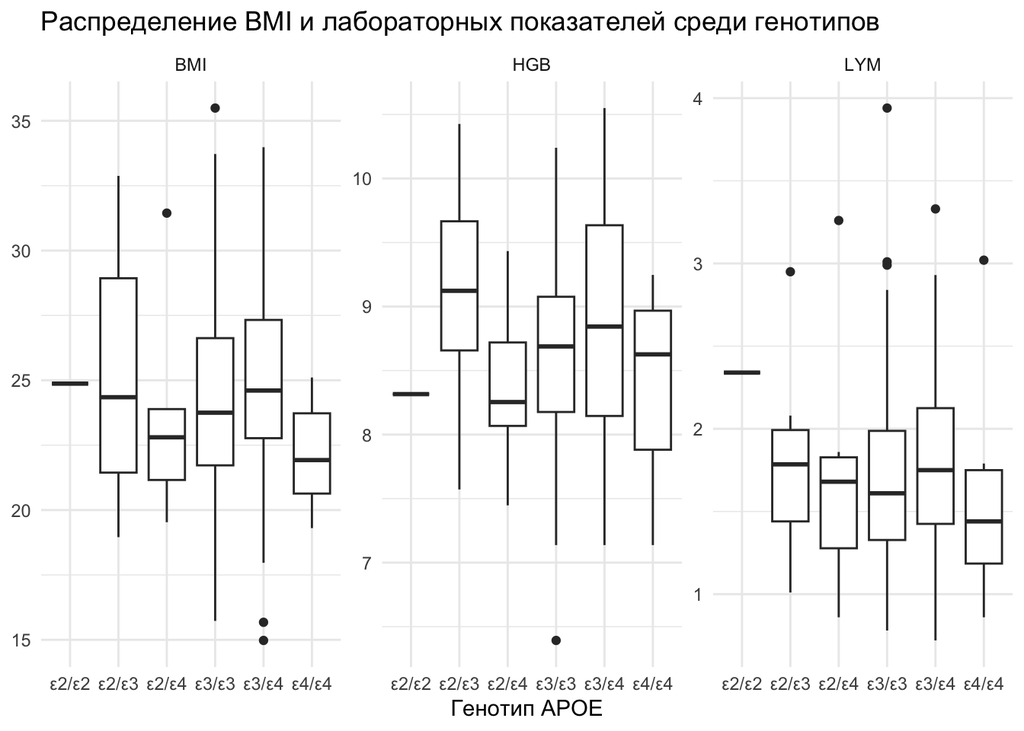

```r
# Боксплоты по BMI, HGB, LYM среди пациентов с разными генотипами

apoe_bmi_long <- apoe_bmi %>%
  select(GT_APOE, BMI, HGB, LYM) %>%
  pivot_longer(
    cols = -GT_APOE,
    names_to = "Показатель",
    values_to = "Значение"
  )

ggplot(apoe_bmi_long, aes(x = GT_APOE, y = Значение)) +
  geom_boxplot() +
  facet_wrap(~ Показатель, scales = "free_y") +
  labs(
    title = 'Распределение BMI и лабораторных показателей среди генотипов',
    x = "Генотип APOE",
    y = NULL
  ) +
  theme_minimal()
```

### 4.2. Таблицы gtsummary

Воспроизведите значения из таблиц раздела 3 с помощью функции `tbl_summary`, настроив статистики и подписи. Изучите документацию к функции [на сайте](https://www.danieldsjoberg.com/gtsummary/articles/tbl_summary.html).

```r
# См. документацию:
# ?tbl_summary
```

### 4.3. Заполнение пропущенных значений

Создайте и загрузите на GitHub экспериментальную ветку `imputation`. В этой ветке перед разделом 3 заполните пропущенные значения количественных показателей, используемых в анализе, средним значением показателя в группе по полу и возрасту. Используйте возрастные группы 50-59, 60-69, 70-79 и 80-89 лет. В дальнейшем анализе используйте датафрейм после заполнения пропусков.